# PREDICTING ERROR IN ZESTIMATES

Maggie Giust

10/15/2017

## IMPORT

ASK -> DEFINE -> **IMPORT** -> TIDY -> TRANSFORM -> EXPLORE -> MODEL -> EXECUTE & COMMUNICATE

Load the data into R for analysis (labeled_properties.csv)

```r
library(tidyverse)
mycolnames <- c("parcelid","typeAC","typeArchitecture","sqftBasement","numBath","numBed","typeBuildingFrame","rankBuildingCondition","numBath1","typeDeck","sqftFinishedFirstFloor","sqftFinishedAll","sqftFinishedAll1","sqftFinishedPerim","sqftFinishedAll2","sqftFinishedFirstFloor1","sqftAll","codeFIPS","numFireplace","numBathFull","numGarage","sqftGarage","boolHottub","typeHeating","locLatitude","locLongitude","sqftLot","numPool","sqftPool","boolHottub1","boolPoolHottub","boolPoolNoHottub","typePropertyUseCounty","typePropertyUseID","typePropertyUseDesc","locCensusTractBlockRaw","locCity","locCounty","locNeighborhood","locZip","numRoom","typeStory","numBath3Q","typeConstruction","numUnits","typePatio","typeShed","yearBuilt","numStories","boolFireplace","valueAssessedStructure","valueAssessedAll","yearTax","valueAssessedLand","valueTax","boolTaxPastDue","yearTaxPastDue","locCensusTractBlock")
prop16 <- read_csv("properties_2016.csv", col_names = mycolnames, skip=1)
prop17 <- read_csv("properties_2017.csv", col_names = mycolnames, skip=1)
tr16 <- read_csv("train_2016_v2.csv")
tr17 <- read_csv("train_2017.csv")
```

## TIDY

ASK -> DEFINE -> IMPORT -> **TIDY** -> TRANSFORM -> EXPLORE -> MODEL -> EXECUTE & COMMUNICATE

### Remove Duplicates

```r
numDups <- function(df) {
  require(dplyr)
  count.vals <- summarise(group_by(df, parcelid),n=n())
  count.dups <- nrow(count.vals[count.vals$n>1,])
  return(count.dups)
}

dups.prop16 <- numDups(prop16)
dups.prop17 <- numDups(prop17)
dups.tr16 <- numDups(tr16)
dups.tr17 <- numDups(tr17)
# numDups(prop16, mycol="parcelid")
```

1. Dups in 2016 property data? 0
2. Dups in 2017 property data? 0
3. Dups in 2016 training data? 124
4. Dups in 2017 training data? 196

### Handle Duplicates

```r
uniq.tr16 <- summarise(group_by(tr16, parcelid), transactiondate=max(transactiondate))
uniq.tr17 <- summarise(group_by(tr17, parcelid), transactiondate=max(transactiondate))
```

### Organize Data Sets

Join data sets: 2016 with 2017 and property details with labels  
**prop** is the data frame on which the final model will be run.  
**tr.prop** is the data frame on which the model will be trained.  
**tr** is the data frame with the labels only, i.e. no features/property details.

```r
# get submission data set

not17.prop16 <- anti_join(prop16, prop17, by=c("parcelid"))
prop <- rbind(not17.prop16, prop17);

not17.tr16 <- anti_join(tr16, tr17, by=c("parcelid"))
tr <- rbind(not17.tr16, tr17);

# remove df's no longer needed
rm(not17.prop16);  rm(not17.tr16); rm(prop16); rm(prop17)
rm(uniq.tr16); rm(uniq.tr17); rm(tr16); rm(tr17)
```

### Summarize the data

#### Header of Property Data Frame

```r
print(head(prop))
```

```
## # A tibble: 6 x 58
##   parcelid typeAC typeArchitecture sqftBasement numBath numBed
##      <int>  <int>            <chr>        <int>   <dbl>  <dbl>
## 1 10754147     NA             <NA>           NA       0      0
## 2 10759547     NA             <NA>           NA       0      0
## 3 10843547     NA             <NA>           NA       0      0
## 4 10859147     NA             <NA>           NA       0      0
## 5 10879947     NA             <NA>           NA       0      0
## 6 10898347     NA             <NA>           NA       0      0
## # ... with 52 more variables: typeBuildingFrame <int>,
## #   rankBuildingCondition <int>, numBath1 <dbl>, typeDeck <int>,
## #   sqftFinishedFirstFloor <int>, sqftFinishedAll <dbl>,
## #   sqftFinishedAll1 <int>, sqftFinishedPerim <int>,
## #   sqftFinishedAll2 <int>, sqftFinishedFirstFloor1 <int>, sqftAll <int>,
## #   codeFIPS <chr>, numFireplace <int>, numBathFull <int>,
## #   numGarage <int>, sqftGarage <int>, boolHottub <chr>,
## #   typeHeating <int>, locLatitude <int>, locLongitude <int>,
## #   sqftLot <dbl>, numPool <int>, sqftPool <int>, boolHottub1 <chr>,
## #   boolPoolHottub <chr>, boolPoolNoHottub <int>,
## #   typePropertyUseCounty <chr>, typePropertyUseID <int>,
## #   typePropertyUseDesc <chr>, locCensusTractBlockRaw <chr>,
## #   locCity <int>, locCounty <int>, locNeighborhood <int>, locZip <int>,
## #   numRoom <dbl>, typeStory <int>, numBath3Q <int>,
## #   typeConstruction <chr>, numUnits <int>, typePatio <int>,
## #   typeShed <int>, yearBuilt <dbl>, numStories <int>,
## #   boolFireplace <chr>, valueAssessedStructure <dbl>,
## #   valueAssessedAll <dbl>, yearTax <int>, valueAssessedLand <dbl>,
## #   valueTax <dbl>, boolTaxPastDue <chr>, yearTaxPastDue <int>,
## #   locCensusTractBlock <dbl>
```

### Summarize the data

#### Summary Statistics of Property details

```r
print(summary(prop))
```

```
##     parcelid             typeAC        typeArchitecture
##  Min.   : 10711725   Min.   : 1.0      Length:2985217
##  1st Qu.: 11643707   1st Qu.: 1.0      Class :character
##  Median : 12545094   Median : 1.0      Mode  :character
##  Mean   : 13325858   Mean   : 1.9
##  3rd Qu.: 14097122   3rd Qu.: 1.0
##  Max.   :169601949   Max.   :13.0
##                      NA's   :2169855
##   sqftBasement        numBath           numBed       typeBuildingFrame
##  Min.   :  20.0    Min.   : 0.000   Min.   : 0.000   Min.   :1.0
##  1st Qu.: 272.0    1st Qu.: 2.000   1st Qu.: 2.000   1st Qu.:3.0
##  Median : 535.0    Median : 2.000   Median : 3.000   Median :4.0
##  Mean   : 647.2    Mean   : 2.216   Mean   : 3.093   Mean   :3.7
##  3rd Qu.: 847.5    3rd Qu.: 3.000   3rd Qu.: 4.000   3rd Qu.:4.0
##  Max.   :8516.0    Max.   :32.000   Max.   :25.000   Max.   :5.0
##  NA's   :2983590   NA's   :2957     NA's   :2945     NA's   :2972486
##  rankBuildingCondition    numBath1         typeDeck
##  Min.   : 1.0          Min.   : 1.0     Min.   :66
##  1st Qu.: 5.0          1st Qu.: 2.0     1st Qu.:66
##  Median : 6.0          Median : 2.0     Median :66
##  Mean   : 6.3          Mean   : 2.3     Mean   :66
##  3rd Qu.: 8.0          3rd Qu.: 3.0     3rd Qu.:66
##  Max.   :12.0          Max.   :32.0     Max.   :66
##  NA's   :1043822       NA's   :117156   NA's   :2967838
##  sqftFinishedFirstFloor sqftFinishedAll  sqftFinishedAll1
##  Min.   :    1          Min.   :     1   Min.   :     1
##  1st Qu.: 1010          1st Qu.:  1215   1st Qu.:  1198
##  Median : 1281          Median :  1574   Median :  1542
##  Mean   : 1380          Mean   :  1832   Mean   :  1764
##  3rd Qu.: 1615          3rd Qu.:  2140   3rd Qu.:  2075
##  Max.   :31303          Max.   :952576   Max.   :427079
##  NA's   :2781459        NA's   :45097    NA's   :264431
##  sqftFinishedPerim sqftFinishedAll2  sqftFinishedFirstFloor1
##  Min.   : 120      Min.   :   112    Min.   :    3
##  1st Qu.: 960      1st Qu.:  1696    1st Qu.: 1012
##  Median :1296      Median :  2173    Median : 1284
##  Mean   :1179      Mean   :  2755    Mean   : 1392
##  3rd Qu.:1440      3rd Qu.:  2975    3rd Qu.: 1619
##  Max.   :2688      Max.   :820242    Max.   :41906
##  NA's   :2977546   NA's   :2795032   NA's   :2781459
```

[output cut: 81 more lines]

```
##  Min.   :2000   Min.   :       1   Min.   :      0   Length:2985217
##  1st Qu.:2016   1st Qu.:   79700   1st Qu.:   2469   Class :character
##  Median :2016   Median :  176619   Median :   4008   Mode  :character
##  Mean   :2016   Mean   :  268456   Mean   :   5409
##  3rd Qu.:2016   3rd Qu.:  326100   3rd Qu.:   6230
##  Max.   :2016   Max.   :94011079   Max.   :3823176
##  NA's   :2933   NA's   :59926      NA's   :22752
##  yearTaxPastDue    locCensusTractBlock
##  Min.   : 0.0      Min.   :-1.000e+00
##  1st Qu.:14.0      1st Qu.: 6.037e+13
##  Median :14.0      Median : 6.038e+13
##  Mean   :13.9      Mean   : 6.048e+13
##  3rd Qu.:15.0      3rd Qu.: 6.059e+13
##  Max.   :99.0      Max.   : 4.830e+14
##  NA's   :2928700   NA's   :74985
```

### Summarize the data

#### Summary Statistics of Training Data

```r
print(summary(tr))
```

```
##     parcelid            logerror        transactiondate
##  Min.   : 10711738   Min.   :-4.65542   Min.   :2016-01-01
##  1st Qu.: 11549292   1st Qu.:-0.02530   1st Qu.:2016-06-06
##  Median : 12542821   Median : 0.00600   Median :2016-10-13
##  Mean   : 12998261   Mean   : 0.01298   Mean   :2016-11-18
##  3rd Qu.: 14220608   3rd Qu.: 0.03830   3rd Qu.:2017-05-15
##  Max.   :167689317   Max.   : 5.26300   Max.   :2017-09-25
```

### Summarize the data

#### Header of Training Data

```r
print(head(tr))
```

```
## # A tibble: 6 x 3
##   parcelid logerror transactiondate
##      <int>    <dbl>          <date>
## 1 11016594   0.0276      2016-01-01
## 2 12098116  -0.0040      2016-01-01
## 3 12643413   0.0218      2016-01-02
## 4 14432541  -0.0050      2016-01-02
## 5 11509835  -0.2705      2016-01-02
## 6 12286022   0.0440      2016-01-02
```

## TRANSFORM

ASK -> DEFINE -> IMPORT -> TIDY -> **TRANSFORM** -> EXPLORE -> MODEL -> EXECUTE & COMMUNICATE

### Data Types

Convert variables with character data type to factor data type

```r
prop <- prop %>% mutate(typeArchitecture = as.factor(typeArchitecture),
                        codeFIPS = as.factor(codeFIPS),
                        typePropertyUseCounty = as.factor(typePropertyUseCounty),
                        typePropertyUseDesc = as.factor(typePropertyUseDesc),
                        typePropertyUseID = as.factor(typePropertyUseID),
                        typeConstruction = as.factor(typeConstruction),
                        typeBuildingFrame = as.factor(typeBuildingFrame),
                        locCensusTractBlockRaw = as.factor(locCensusTractBlockRaw),
                        locCensusTractBlock = as.factor(locCensusTractBlock))
```

### Remove variables

Too many missing values:

- type: AC, Architecture, BuildingFrame, Heating, Construction
- num: Stories, Room
- sqft: Basement, FinishedFirstFloor, FinishedFirstFloor1, FinishedPerim

Zero or near-zero variance:

High correlation or linear dependence:

- sqft: All, FinishedAll1, FinishedAll2, Garage
- num: Bath1, BathFull, Bath3Q
- locCensusTractBlock

```r
rmcols <- c("typeAC", "typeArchitecture", "typeConstruction","typeBuildingFrame",
            "typeHeating","typeStory",
            "numStories","numRoom","numBath1", "numBathFull", "numBath3Q",
            "sqftBasement","sqftFinishedFirstFloor","sqftFinishedFirstFloor1", "sqftFinishedPerim",
            "sqftFinishedAll1", "sqftFinishedAll2", "sqftAll", "sqftGarage",
            "locCensusTractBlock")
prop <- select(prop, -one_of(rmcols))
```

## Normalize boolean variables:

- fill missing values with 0
- boolFireplace, boolHottub, boolTaxPastDue: convert ‘true’/‘Y’ to 1 & type to number.
- boolPoolHottub, boolPoolNoHottub: Merge into “has Pool”
- boolHottub, boolHottub1, boolPoolHottub: Merge into “has Hot Tub”
- convert to factor.

```r
prop <- prop %>% mutate(boolFireplace = parse_integer(ifelse(is.na(boolFireplace),0,1)),
                        boolHottub = parse_integer(ifelse(is.na(boolHottub),0,1)),
                        boolTaxPastDue = parse_integer(ifelse(is.na(boolTaxPastDue),0,1))) %>%
  mutate(hasPool = ifelse(boolPoolHottub==1 | boolPoolNoHottub==1, 1, 0),
         hasHottub = ifelse(boolHottub==1 | boolHottub1==1 | boolPoolHottub==1, 1, 0)) %>%
  mutate(hasFireplace = as.factor(boolFireplace),
         hasHottub = as.factor(hasHottub),
         hasPool = as.factor(hasPool),
         hasTaxPastDue = as.factor(boolTaxPastDue)) %>%
  select(-boolFireplace, -boolHottub, -boolPoolHottub, -boolPoolNoHottub, -boolHottub1, -boolTaxPastDue)
```

## Variables where missing indicates 0

numPool, numGarage, numFireplace, typeDeck, typePatio, typeShed, yearTaxPastDue

```r
prop <- prop %>% mutate(numPool = ifelse(is.na(numPool),0,1),
                        numGarage = ifelse(is.na(numGarage),0,numGarage),
                        numFireplace = ifelse(is.na(numFireplace),0,numFireplace),
                        typeDeck = ifelse(is.na(typeDeck),0,1),
                        typePatio = ifelse(is.na(typePatio),0,1),
                        typeShed = ifelse(is.na(typeShed),0,1),
                        yearTaxPastDue = ifelse(is.na(yearTaxPastDue),0,1))
```

## Merge multiple variables into single variable

- typeDeck, typePatio, typeShed: “hasDeckPatioShed”
- numFireplace & hasFireplace: “hasFireplace”
- sqftPool, numPool, hasPool: “hasPool”
- hasTaxPastDue, yearTaxPastDue: “hasTaxPastDue”

```r
prop <- prop %>% mutate(hasDeckPatioShed = ifelse(typeDeck==1 | typePatio==1 | typeShed==1, 1, 0),
                        hasFireplace = ifelse(hasFireplace==1 | numFireplace>0, 1, 0),
                        hasPool = ifelse(hasPool==1 | numPool==1 | sqftPool>0, 1, 0),
                        hasTaxPastDue = ifelse(hasTaxPastDue==1 | yearTaxPastDue==1, 1, 0)) %>%
  select(-typeDeck, -typePatio, -typeShed, -numFireplace, -numPool, -yearTaxPastDue)
```

## Pool & Hot Tub

sqftPool, hasPool, hasHottub

- For sqftPool, if HotTub and no Pool, estimate 25 sqft, if Pool and no square feet, estimate 495 square feet (median).

```r
prop <- prop %>% mutate(sqftPool = ifelse(sqftPool>0, sqftPool,
                                          ifelse(hasPool==1, 495,
                                                 ifelse(hasHottub==1, 25, 0)))) %>%
  select(-hasPool, -hasHottub)
```

## Other missing values

- numUnits -> 1
- rankBuildingCondition -> 6
- typePropertyUseID -> 261
- typePropertyUseCounty -> 0100
- typePropertyUseDesc -> LAR1
- locNeighborhood -> convert to 0 if no value, 1 if value

```r
prop <- prop %>% mutate(numUnits = ifelse(is.na(numUnits), 1, numUnits),
                        rankBuildingCondition = ifelse(is.na(rankBuildingCondition),
                                                       6, rankBuildingCondition),
                        typePropertyUseCounty = as.character(typePropertyUseCounty),
                        typePropertyUseDesc = as.character(typePropertyUseDesc),
                        typePropertyUseID = as.character(typePropertyUseID)) %>%
  mutate(typePropertyUseCounty = ifelse(is.na(typePropertyUseCounty), "0100",
                                        typePropertyUseCounty),
         typePropertyUseDesc = ifelse(is.na(typePropertyUseDesc), "LAR1", typePropertyUseDesc),
         typePropertyUseID = ifelse(is.na(typePropertyUseID), "261", typePropertyUseID),
         hasNeighborhood = ifelse(is.na(locNeighborhood), 0, 1)) %>%
  mutate(typePropertyUseCounty = as.factor(typePropertyUseCounty),
         typePropertyUseDesc = as.factor(typePropertyUseDesc),
         typePropertyUseID = as.factor(typePropertyUseID)) %>%
  select(-locNeighborhood)
```

## rankBuildingCondition

group into a smaller spread

```r
prop <- prop %>% mutate(rankBuildingCondition =
                          ifelse(rankBuildingCondition < 4, 1,
                                 ifelse(rankBuildingCondition < 7, 2,
                                        ifelse(rankBuildingCondition < 10, 3, 4))))
```

## City & Zip

- locZip: odd max value of 399675 looks like a data quality issue

```r
summary(prop$locZip)
```

```
##    Min. 1st Qu.  Median    Mean 3rd Qu.    Max.    NA's
##   95982   96180   96377   96553   96974  399675   12714
```

- Find cities where zip is 399675

```r
cities <- unique(prop[prop$locZip==399675,]$locCity)
cities <- cities[!is.na(cities)]
cityzip <- select(prop[prop$locCity %in% cities,],locZip,locCity)
table(cityzip$locZip, cityzip$locCity)
```

```
##
##          14906 24435 32923
##   96267      0     0   444
##   96270      4  5434    61
##   96273     81     2  9889
##   399675   340    91     2
```

- Replace with expected zip for that city

```r
prop <- prop %>% mutate(locZip =
                          ifelse(locZip==399675 & locCity==24435, 96270,
                                 ifelse(locZip==399675, 96273,
                                        locZip)))
```

## Year Built

- convert yearBuilt into age of the property, grouping by 10 years

```r
prop <- prop %>% mutate(age = round((2018-yearBuilt)/10,0))
# take a peek
table(prop$age)
```

```
##
##      0      1      2      3      4      5      6      7      8      9
##  25019 131220 211322 320489 418755 349264 611402 388411 166702 154956
##     10     11     12     13     14     15     16     17     18     19
## 107521  43019   7487   1625    113     11     17      2      5     13
##     20     21     22
##     13     14      4
```

```r
# bin 11+ into 1 bucket
prop <- prop %>% mutate(age = ifelse(age>=11, 11, age))
```

## Impute Median Values

- numBed, numBath
- locLatitude, locLongitude, locCounty
- sqftFinishedAll, sqftLot
- valueAssessedStructure, valueAssessedAll, valueAssessedLand, valueTax

## EXPLORE

ASK -> DEFINE -> IMPORT -> TIDY -> TRANSFORM -> **EXPLORE** -> MODEL -> EXECUTE & COMMUNICATE

### Target Variable: What are we predicting?

LOGERROR of Zestimate

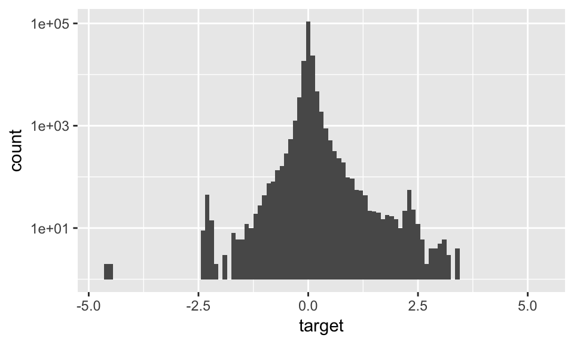

```r
tr.df <- left_join(tr,prop,by=c("parcelid"))
target <- tr.df$logerror
ggplot(data=tr.df, aes(x=target)) +
   geom_histogram(binwidth = .1) +
   scale_y_log10()
```

## Bed, Bath, Size

Do number of bedrooms (numBed), number of baths (numBath), and square feet (sqftFinishedAll) depend on each other? If so, I will want to either select one to use or find a way to merge these 3 variables into a single variable/feature.

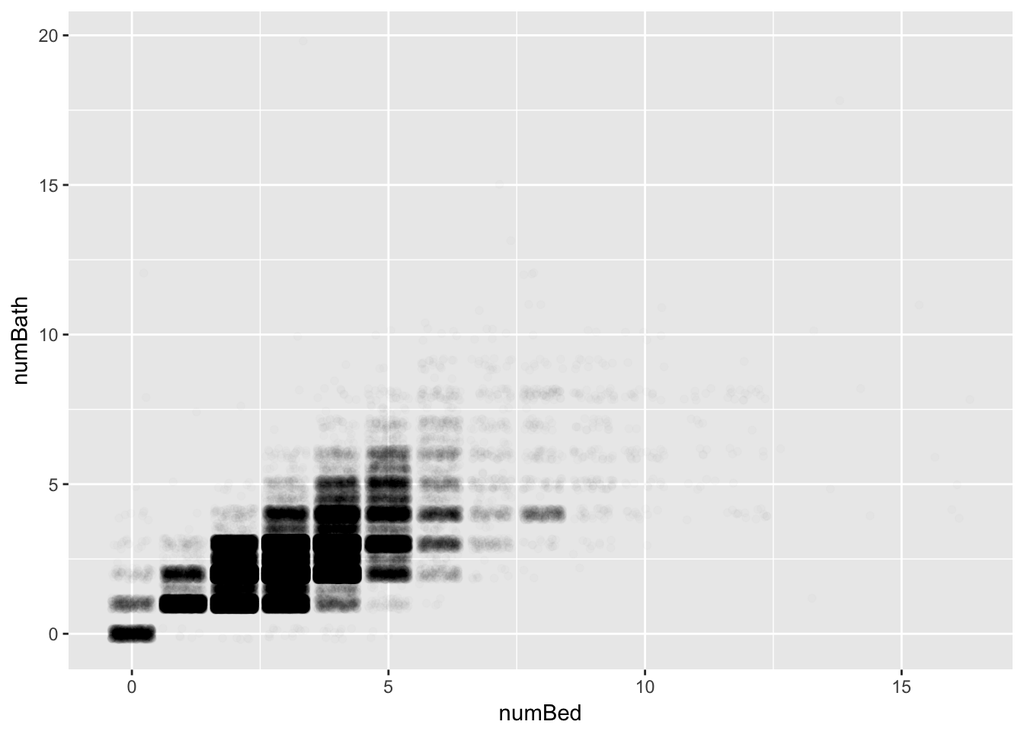

```r
ggplot(tr.df, aes(x=numBed, y=numBath)) +
  geom_jitter(alpha=1/100)
```

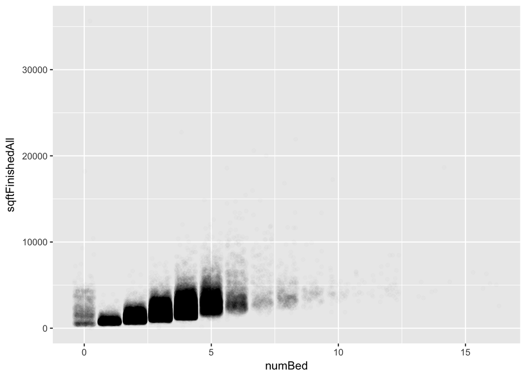

```r
ggplot(tr.df, aes(x=numBed, y=sqftFinishedAll)) +
  geom_jitter(alpha=1/100)
```

```r
house.lm <- lm(sqftFinishedAll ~ numBed + numBath,
               data=tr.df[tr.df$numBed>0 & tr.df$numBath>0,])
cod <- summary(house.lm)$r.squared
```

### Extremes in LogError

My hypothesis is that by finding those attributes that differ the most across the group with the largest error and that with the smalles, I will be closer to identifying the biggest drivers in the error (logerror).  
I use the absolute logerror in order to take the “bottom 10%” indicating those with minimal error.  
I then take the lower 5% (of true logerror) and upper 5% of true logerror.

### Extremes in LogError

#### Bed, Bath, Size, Units

As the total number of Beds + Baths increase, accuracy decreases.

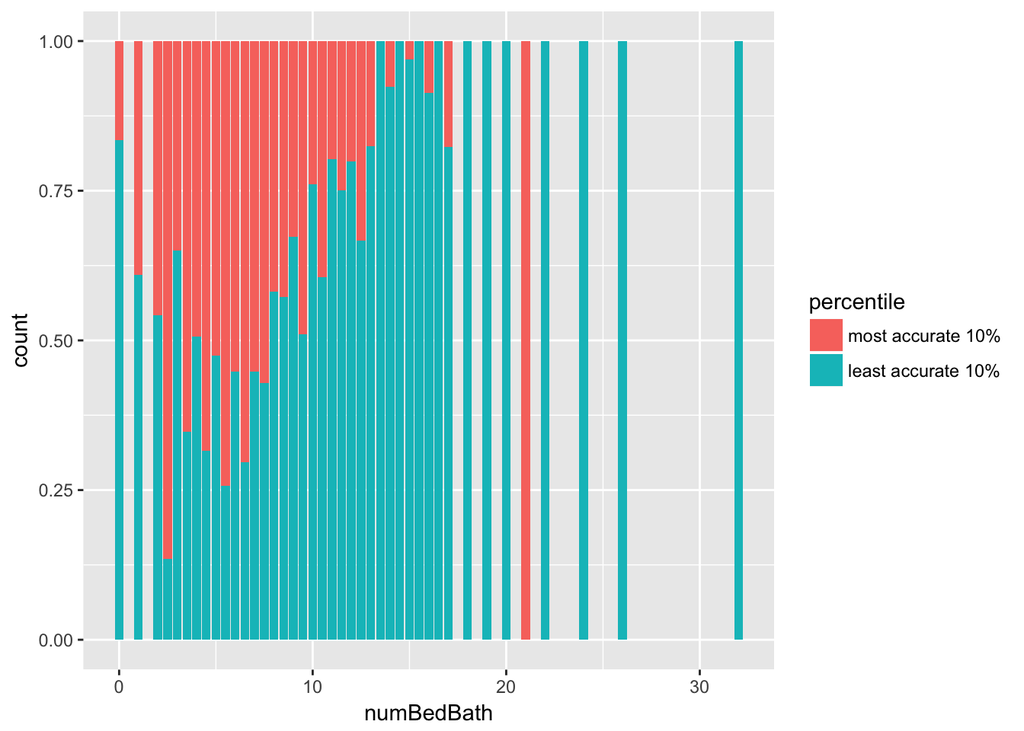

```r
tr.df <- tr.df %>% mutate(numBedBath=numBed+numBath)
data <- tr.df[tr.df$percentile!="middle 80%",]

ggplot(data, aes(x=numBedBath)) +
  geom_bar(aes(fill=percentile), position="fill")
```

### Extremes in LogError

#### Bed, Bath, Size, Units

The increased error seems to be with anamolous combinations of bed+bath+sqft.  
E.g. unexpected number of beds or baths with the square feet of the home.

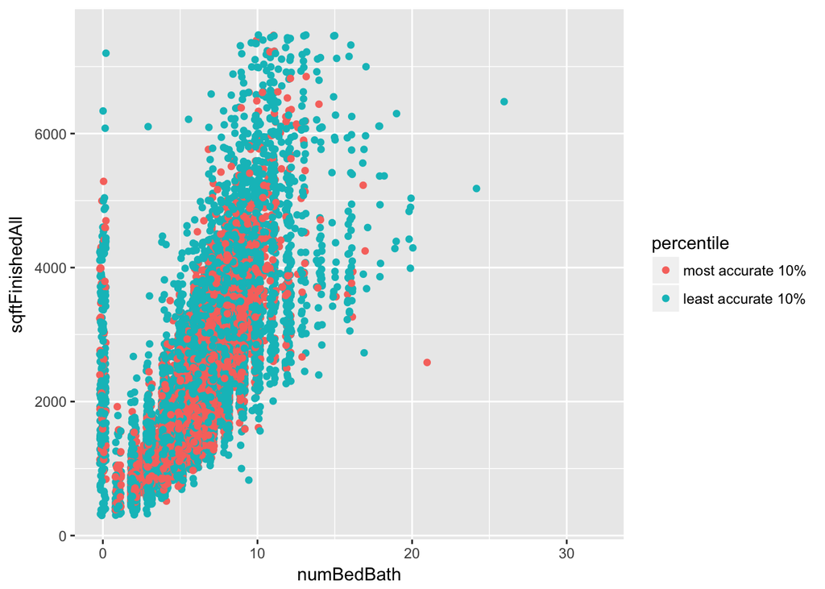

```r
ggplot(data, aes(x=numBedBath, y=sqftFinishedAll)) +
  geom_jitter(aes(color=percentile)) +
  scale_y_continuous(limits=c(300,7500))
```

### Extremes in LogError

#### Annual Tax Owed

- Higher tax value, higher error

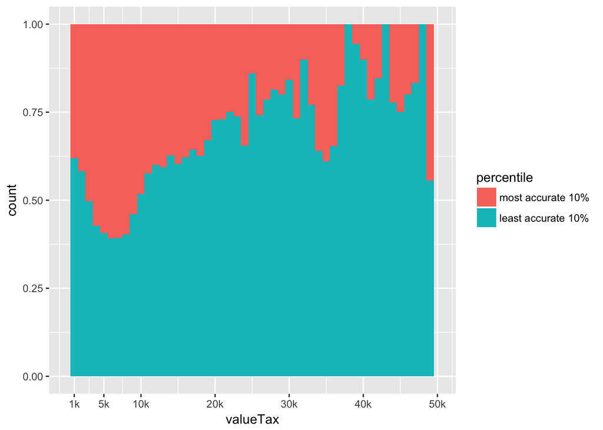

```r
ggplot(data, aes(x=valueTax)) +
  geom_histogram(aes(fill=percentile), binwidth = 1000, position="fill") +
  scale_x_continuous(breaks=c(1000,5000,10000,20000,30000,40000,50000),
                     labels = c("1k","5k","10k","20k","30k","40k","50k"),
                     limits = c(100,50000))
```

### Extremes in LogError

#### Tax Past Due

- those with taxes past due have a higher error. foreclosures?

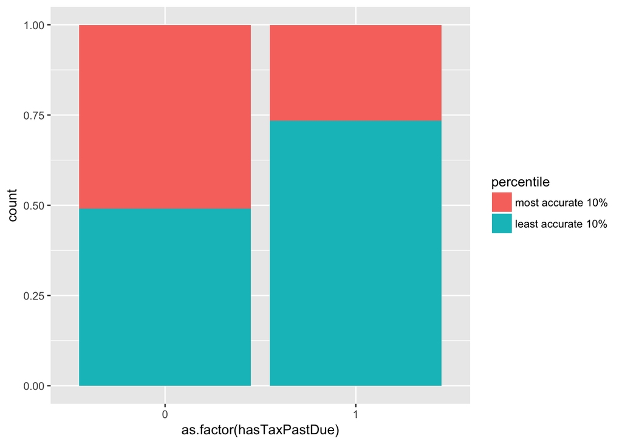

```r
ggplot(data, aes(x=as.factor(hasTaxPastDue))) +
  geom_bar(aes(fill=percentile), position="fill")
```

### Extremes in LogError

#### FIPS & Location County

FIPS: 06037 = Los Angeles County  
FIPS: 06059 = Orange County  
FIPS: 06111 - Ventura County

We can see the largest number of errors occur in LA County.  
Not surprising to me, as that has the most diverse properties.

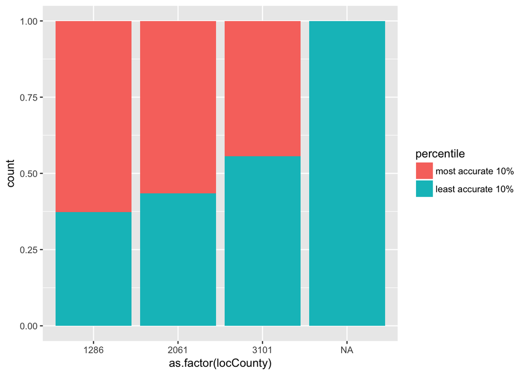

```r
ggplot(data, aes(x=as.factor(locCounty))) +
  geom_bar(aes(fill=percentile), position="fill")
```

### Extremes in LogError

#### Age of the Property

Older homes are more difficult to predict.

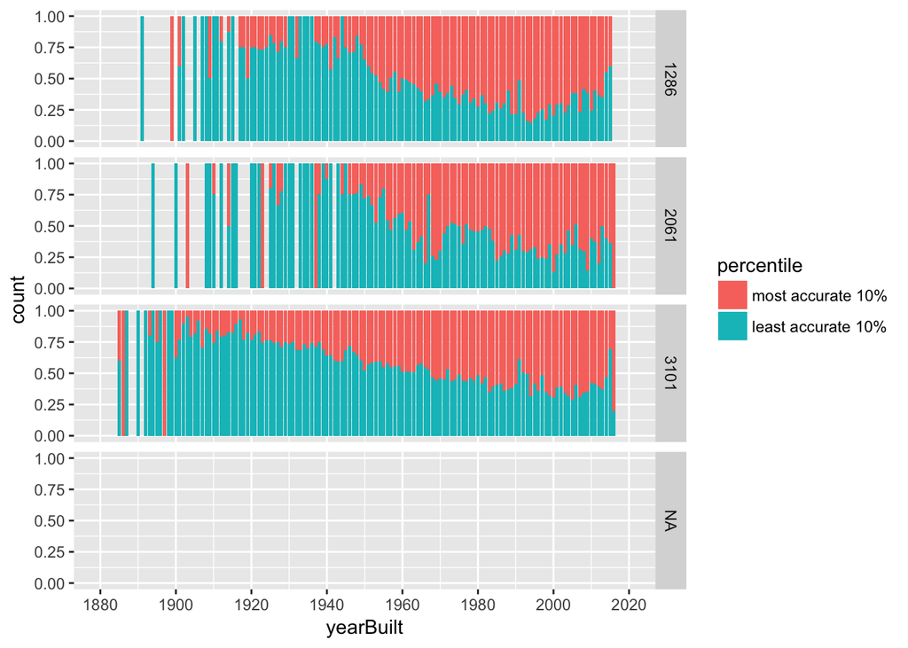

```r
ggplot(data, aes(x=yearBuilt)) +
  geom_bar(aes(fill=percentile), position="fill") +
  scale_x_continuous(breaks=c(1880,1900,1920,1940,1960,1980,2000,2020),
                     limits=c(1880,2020)) +
  facet_grid(locCounty~.)
```

### Extremes in LogError

#### Assessed Value of Property

Higher value, higher error

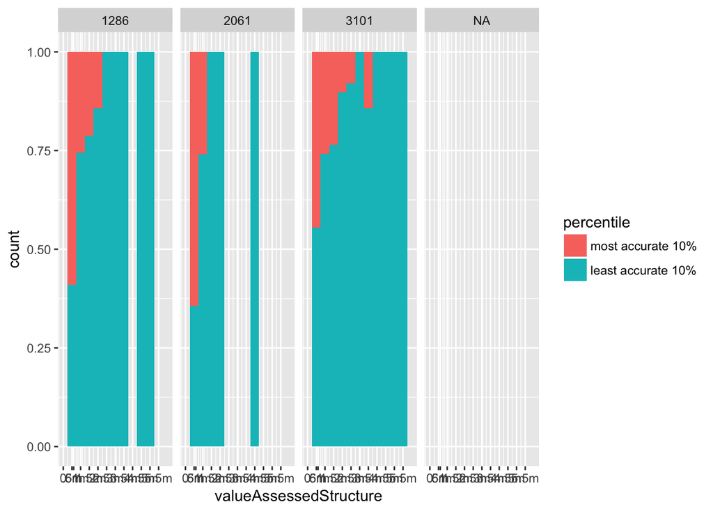

```r
ggplot(data, aes(x=valueAssessedStructure)) +
  geom_histogram(aes(fill=percentile), binwidth = 500000, position="fill") +
  scale_x_continuous(breaks=c(0,500000,1000000,1500000,2000000,2500000,3000000,3500000,4000000,4500000,5000000,5500000,
                              600000),
                     labels=c("0",".5m","1m","1.5m","2m","2.5m","3m","3.5m","4m","4.5m","5m","5.5m","6m"),
                     limits=c(0,6000000)) +
  facet_grid(.~locCounty)
```

### Clustering By County

Prepare the latitude and longitude data to be able to cluster the data.

```r
tr.df <- tr.df %>% mutate(
  locCounty=ifelse(
    codeFIPS=="06037",  "Los Angeles County",
    ifelse(codeFIPS=="06059", "Orange County",
           ifelse(codeFIPS=="06111", "Ventura County", codeFIPS)))) %>%
  mutate(locCounty=as.factor(locCounty))

library(plyr)

tr.df <- tr.df %>% ddply(.(locCounty), transform,
                         mean.lat = mean(locLatitude),
                         sd.lat = sd(locLatitude),
                         mean.lon = mean(locLongitude),
                         sd.lon = sd(locLongitude)) %>%
  ddply(.(locCounty), transform,
        locLatNorm = (locLatitude - mean.lat)/sd.lat,
        locLonNorm = (locLongitude - mean.lon)/sd.lon)

library(fpc)
tr.df <- tr.df[!is.na(tr.df$locLatNorm),]
tr.vc <- select(tr.df[tr.df$locCounty=="Ventura County",],
                   locLatNorm,locLonNorm)
tr.oc <- select(tr.df[tr.df$locCounty=="Orange County",],
                   locLatNorm,locLonNorm)
tr.la <- select(tr.df[tr.df$locCounty=="Los Angeles County",]
                   ,locLatNorm,locLonNorm)
```

### Clustering By County

#### Ventura County

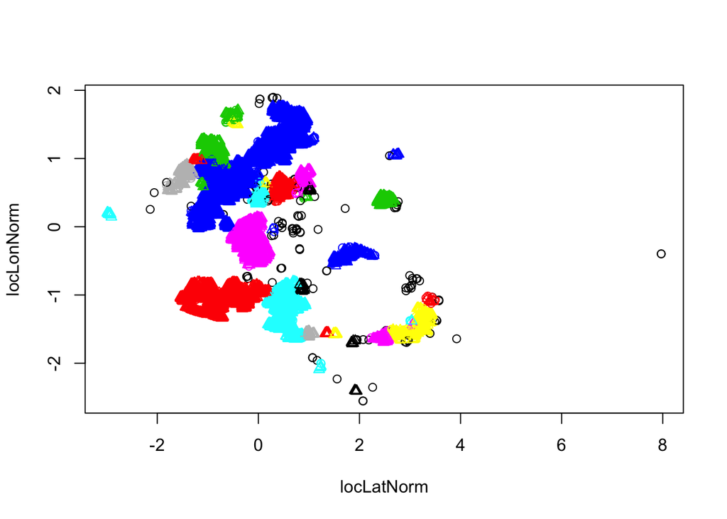

```r
ds.vc <- dbscan(tr.vc, 0.05)
plot(ds.vc, tr.vc)
```

### Clustering By County

#### Orange County

```r
# ds.oc <- dbscan(tr.oc, 0.03)
# plot(ds.oc, tr.oc)
```

### Clustering By County

#### Los Angeles County

```r
# ds.la <- dbscan(tr.la, 0.018)
# plot(ds.la, tr.la)
```

## MODEL

ASK -> DEFINE -> IMPORT -> TIDY -> TRANSFORM -> EXPLORE -> **MODEL** -> EXECUTE & COMMUNICATE

### Get training data

```r
tr.prop <- left_join(tr, prop, by=c("parcelid"))
tr <- tr.prop[tr.prop$transactiondate<"2016-10-01" |
                tr.prop$transactiondate>="2017-01-01",]
```

### Impute Missing Values

```r
library(caret)
imputeVals <- preProcess(tr, method=c("medianImpute"))
preproc.tr.prop <- predict(imputeVals, tr.prop)
preproc.tr <- preproc.tr.prop[preproc.tr.prop$transactiondate<"2016-10-01" |
                                preproc.tr.prop$transactiondate>="2017-01-01",]
```

### Add New Features

```r
require(geosphere); require(stringr); require(Metrics); require(caret)
# require(catboost);
# don't use scientific notation when printing out
options(scipen=999)

preproc.tr <- preproc.tr %>% mutate(
  sqftNetLiving = sqftFinishedAll-(120*numBed+30*numBath),
  ratioLandValue = valueAssessedLand/
                    (valueAssessedLand + valueAssessedStructure),
  bathPower = numBath * sqftFinishedAll,
      # sqft per room
  sqftPerBed = sqftFinishedAll/max(numBed,1),
      # sqft as ratio of lot size
  sqftStructureToLot = sqftFinishedAll/sqftLot,
  longmean = mean((locLongitude), na.rm=TRUE)/1e6,
  latmean = mean((locLatitude), na.rm=TRUE)/1e6,
  longitude = locLongitude/1e6,
  latitude = locLatitude/1e6)

preproc.tr$geodist = distHaversine(preproc.tr[,38:39], preproc.tr[,40:41])
```

### Remove variables

- factors (for now…could use these to ensemble a model on top of regression)
- linear dependent (used to create new features)

```r
preproc.tr <- select(preproc.tr, logerror, parcelid, locCounty, numBath, numBed, numGarage, numUnits,
                     rankBuildingCondition, valueAssessedAll,
                     sqftFinishedAll, sqftLot, sqftPool, sqftNetLiving, sqftPerBed, sqftStructureToLot,
                     hasFireplace, hasTaxPastDue, hasDeckPatioShed, hasNeighborhood,
                     age, ratioLandValue, bathPower, geodist)
```

### Normalize By Column

```r
vars <- preproc.tr[,4:23]
colMean <- apply(vars,2,mean)
colSD <- apply(vars,2,sd)

vars.norm <- as.data.frame(lapply(vars[,1], function(x) (x-colMean[1])/colSD[1]))
colnames(vars.norm) <- colnames(vars[1:1])

for (i in (2:length(vars))) {
  vars.norm <- cbind(vars.norm, as.data.frame(lapply(vars[,i], function(x) (x-colMean[i])/colSD[i])))
  colnames(vars.norm) <- colnames(vars[1:i])
}

preproc.tr <- cbind(preproc.tr[,1:3],vars.norm)
```

### Create Function for Evaluation Metric

MAE: Mean Absolute Error

```r
maeSummary <- function (data,
                       lev = NULL,
                       model = NULL) {
  out <- mae(data$obs, data$pred)
  names(out) <- "MAE"
  out
  }
```

### Train Control Parameters

```r
zControl <- trainControl(method = "repeatedcv",
                         number = 10,
                         repeats = 10,
                         search = "random",
                         verboseIter = FALSE,
                         returnResamp = "all",
                         savePredictions = TRUE,
                         summaryFunction = maeSummary,
                         predictionBounds = c(TRUE,TRUE))
```

### Subset by County

```r
tr1 <- select(preproc.tr[preproc.tr$locCounty==3101,], -parcelid, -locCounty)
tr2 <- select(preproc.tr[preproc.tr$locCounty==1286,], -parcelid, -locCounty)
tr3 <- select(preproc.tr[preproc.tr$locCounty==2061,], -parcelid, -locCounty)
```

### PreProcess (by County)

```r
library(fastICA)
set.seed(1234)
preProcValues1 <- preProcess(tr1[,-1], method = c("nzv","ica"), n.comp=2)
proc.tr1 <- predict(preProcValues1, tr1[,-1])
proc.tr1 <- cbind(logerror=tr1[,1],proc.tr1)
set.seed(1234)
preProcValues2 <- preProcess(tr2[,-1], method = c("nzv","ica"), n.comp=2)
proc.tr2 <- predict(preProcValues2, tr2[,-1])
proc.tr2 <- cbind(logerror=tr2[,1],proc.tr2)
set.seed(1234)
preProcValues3 <- preProcess(tr3[,-1], method = c("nzv","ica"), n.comp=2)
proc.tr3 <- predict(preProcValues3, tr3[,-1])
proc.tr3 <- cbind(logerror=tr3[,1],proc.tr3)
```

### Train a Linear Model

```r
set.seed(1234)
zmod_lm1 <- train(logerror ~ .,
                 data = proc.tr1,
                 method = "lm",
                 metric = "MAE",
                 maximize = FALSE,
                 trControl = zControl
                 )

set.seed(1234)
zmod_lm2 <- train(logerror ~ .,
                 data = proc.tr2,
                 method = "lm",
                 metric = "MAE",
                 maximize = FALSE,
                 trControl = zControl
                 )

set.seed(1234)
zmod_lm3 <- train(logerror ~ .,
                 data = proc.tr3,
                 method = "lm",
                 metric = "MAE",
                 maximize = FALSE,
                 trControl = zControl
                 )
zmod_lm1
```

```
## Linear Regression
##
## 102113 samples
##      2 predictor
##
## No pre-processing
## Resampling: Cross-Validated (10 fold, repeated 10 times)
## Summary of sample sizes: 91902, 91902, 91902, 91901, 91902, 91901, ...
## Resampling results:
##
##   MAE
##   0.07355998
##
## Tuning parameter 'intercept' was held constant at a value of TRUE
```

```r
zmod_lm2
```

```
## Linear Regression
##
## 42468 samples
##     2 predictor
##
## No pre-processing
## Resampling: Cross-Validated (10 fold, repeated 10 times)
## Summary of sample sizes: 38222, 38221, 38221, 38220, 38222, 38220, ...
## Resampling results:
##
##   MAE
##   0.05924397
##
## Tuning parameter 'intercept' was held constant at a value of TRUE
```

```r
zmod_lm3
```

```
## Linear Regression
##
## 12637 samples
##     2 predictor
##
## No pre-processing
## Resampling: Cross-Validated (10 fold, repeated 10 times)
## Summary of sample sizes: 11374, 11373, 11373, 11373, 11373, 11373, ...
## Resampling results:
##
##   MAE
##   0.06245485
##
## Tuning parameter 'intercept' was held constant at a value of TRUE
```

### Train a Robust Linear Model

```r
set.seed(1234)
zmod_rlm1 <- train(logerror ~ .,
                 data = proc.tr1,
                 method = "rlm",
                 metric = "MAE",
                 maximize = FALSE,
                 trControl = zControl
                 )

set.seed(1234)
zmod_rlm2 <- train(logerror ~ .,
                 data = proc.tr2,
                 method = "rlm",
                 metric = "MAE",
                 maximize = FALSE,
                 trControl = zControl
                 )

set.seed(1234)
zmod_rlm3 <- train(logerror ~ .,
                 data = proc.tr3,
                 method = "rlm",
                 metric = "MAE",
                 maximize = FALSE,
                 trControl = zControl
                 )
zmod_rlm1
```

```
## Robust Linear Model
##
## 102113 samples
##      2 predictor
##
## No pre-processing
## Resampling: Cross-Validated (10 fold, repeated 10 times)
## Summary of sample sizes: 91902, 91902, 91902, 91901, 91902, 91901, ...
## Resampling results across tuning parameters:
##
##   intercept  psi         MAE
##   FALSE      psi.huber   0.07335488
##    TRUE      psi.huber   0.07310385
##    TRUE      psi.hampel  0.07311847
##
## MAE was used to select the optimal model using  the smallest value.
## The final values used for the model were intercept = TRUE and psi
##  = psi.huber.
```

```r
zmod_rlm2
```

```
## Robust Linear Model
##
## 42468 samples
##     2 predictor
##
## No pre-processing
## Resampling: Cross-Validated (10 fold, repeated 10 times)
## Summary of sample sizes: 38222, 38221, 38221, 38220, 38222, 38220, ...
## Resampling results across tuning parameters:
##
##   intercept  psi         MAE
##   FALSE      psi.huber   0.05884214
##    TRUE      psi.huber   0.05838727
##    TRUE      psi.hampel  0.05838297
##
## MAE was used to select the optimal model using  the smallest value.
## The final values used for the model were intercept = TRUE and psi
##  = psi.hampel.
```

```r
zmod_rlm3
```

```
## Robust Linear Model
##
## 12637 samples
##     2 predictor
##
## No pre-processing
## Resampling: Cross-Validated (10 fold, repeated 10 times)
## Summary of sample sizes: 11374, 11373, 11373, 11373, 11373, 11373, ...
## Resampling results across tuning parameters:
##
##   intercept  psi         MAE
##   FALSE      psi.huber   0.06185687
##    TRUE      psi.huber   0.06146593
##    TRUE      psi.hampel  0.06145516
##
## MAE was used to select the optimal model using  the smallest value.
## The final values used for the model were intercept = TRUE and psi
##  = psi.hampel.
```

### Final Decisions

#### Features

- locCounty, geodist
- numBath, bathPower, numBed, numGarage, numUnits
- rankBuildingCondition, age
- valueAssessedAll, ratioLandValue
- sqftFinishedAll, sqftLot, sqftPool, sqftNetLiving, sqftPerBed, sqftStructureToLot
- hasFireplace, hasTaxPastDue, hasDeckPatioShed, hasNeighborhood

#### Model

- Robust Linear Model

#### Parameters & Details

- Preprocess by normalizing each column independently based on each columns mean & standard deviation calculated from the training set.
- Impute values using median impute method
- Preprocess using “nzv” (near-zero value),“ica” (independent component analysis) with 2 components, and “center” & “scale” (done as a substep of ICA)
- Increase sampling through repeated cross validation, over 10 resampling iterations, computing 10 complete sets of folds in each iteration.
- Evaluate performance using MAE
- Set prediction bounds to be existing max and min from Training data.
- Divide the dataset by county…each county has it’s own model.

### Run Robust Linear Model over Test Data

#### Generate Test Data

```r
ts.prop <- preproc.tr.prop[preproc.tr.prop$transactiondate>="2016-10-01" &
                             preproc.tr.prop$transactiondate<"2017-01-01",]
```

#### Features

```r
ts.prop <- ts.prop %>% mutate(
  sqftNetLiving = sqftFinishedAll-(120*numBed+30*numBath),
  ratioLandValue = valueAssessedLand/
                    (valueAssessedLand + valueAssessedStructure),
  bathPower = numBath * sqftFinishedAll,
      # sqft per room
  sqftPerBed = sqftFinishedAll/max(numBed,1),
      # sqft as ratio of lot size
  sqftStructureToLot = sqftFinishedAll/sqftLot,
  longmean = mean((locLongitude), na.rm=TRUE)/1e6,
  latmean = mean((locLatitude), na.rm=TRUE)/1e6,
  longitude = locLongitude/1e6,
  latitude = locLatitude/1e6)

ts.prop$geodist = distHaversine(ts.prop[,38:39], ts.prop[,40:41])

ts.prop <- ts.prop[,c(2,1,19,4:5,9,21,6,24,7,12:13,33,36:37,28:32,34:35,42)]
```

#### Normalize values by column based on parameters from training data

```r
vars <- ts.prop[,4:23]
vars.norm <- as.data.frame(lapply(vars[,1], function(x) (x-colMean[1])/colSD[1]))
colnames(vars.norm) <- colnames(vars[1:1])

for (i in (2:length(vars))) {
  vars.norm <- cbind(vars.norm, as.data.frame(lapply(vars[,i], function(x) (x-colMean[i])/colSD[i])))
  colnames(vars.norm) <- colnames(vars[1:i])
}

ts.prop <- cbind(ts.prop[,1:3],vars.norm)
```

#### Break up by County

```r
ts1 <- ts.prop[ts.prop$locCounty==3101,]; ts1 <- ts1[,-c(2:3)]
ts2 <- ts.prop[ts.prop$locCounty==1286,]; ts2 <- ts2[,-c(2:3)]
ts3 <- ts.prop[ts.prop$locCounty==2061,]; ts3 <- ts3[,-c(2:3)]
```

```r
proc.ts1 <- predict(preProcValues1, ts1[,-1])
proc.ts1 <- cbind(logerror=ts1[,1],proc.ts1)
proc.ts2 <- predict(preProcValues2, ts2[,-1])
proc.ts2 <- cbind(logerror=ts2[,1],proc.ts2)
proc.ts3 <- predict(preProcValues3, ts3[,-1])
proc.ts3 <- cbind(logerror=ts3[,1],proc.ts3)
```

#### Predict LogError on Test Data using zmod_rlm

```r
pred1 <- predict(zmod_rlm1, proc.ts1)
pred2 <- predict(zmod_rlm2, proc.ts2)
pred3 <- predict(zmod_rlm3, proc.ts3)
```

#### Evaluate MAE of LogError vs. Predicted LogError

```r
pred_rlm <- rbind(cbind(ts.prop[ts.prop$locCounty==3101,][,c(1:2)],
                        logerror_hat = pred1),
                  cbind(ts.prop[ts.prop$locCounty==1286,][,c(1:2)],
                        logerror_hat = pred2),
                  cbind(ts.prop[ts.prop$locCounty==2061,][,c(1:2)],
                        logerror_hat = pred3))
mae(pred_rlm$logerror, pred_rlm$logerror_hat)
```

```
## [1] 0.06321727
```

## EXECUTE

ASK -> DEFINE -> IMPORT -> TIDY -> TRANSFORM -> EXPLORE -> MODEL -> **EXECUTE** & COMMUNICATE

#### Using Complete Data Set, Impute Values

```r
preproc.prop <- predict(imputeVals, prop)
```

#### Features

```r
preproc.prop <- preproc.prop %>% mutate(
  sqftNetLiving = sqftFinishedAll-(120*numBed+30*numBath),
  ratioLandValue = valueAssessedLand/
                    (valueAssessedLand + valueAssessedStructure),
  bathPower = numBath * sqftFinishedAll,
      # sqft per room
  sqftPerBed = sqftFinishedAll/max(numBed,1),
      # sqft as ratio of lot size
  sqftStructureToLot = sqftFinishedAll/sqftLot,
  longmean = mean((locLongitude), na.rm=TRUE)/1e6,
  latmean = mean((locLatitude), na.rm=TRUE)/1e6,
  longitude = locLongitude/1e6,
  latitude = locLatitude/1e6)

preproc.prop$geodist = distHaversine(preproc.prop[,36:37], preproc.prop[,38:39])

preproc.prop <- preproc.prop[,c(1,17,2:3,7,19,4,22,5,10:11,31,34:35,26:30,32:33,40)]
```

#### Normalize values by column based on parameters from training data

```r
vars <- preproc.prop[,3:22]
vars.norm <- as.data.frame(lapply(vars[,1], function(x) (x-colMean[1])/colSD[1]))
colnames(vars.norm) <- colnames(vars[1:1])

for (i in (2:length(vars))) {
  vars.norm <- cbind(vars.norm, as.data.frame(lapply(vars[,i], function(x) (x-colMean[i])/colSD[i])))
  colnames(vars.norm) <- colnames(vars[1:i])
}

preproc.prop <- cbind(preproc.prop[,1:2],vars.norm)
```

#### Break up by County

```r
prop1 <- preproc.prop[preproc.prop$locCounty==3101,][,-c(1:2)]
prop2 <- preproc.prop[preproc.prop$locCounty==1286,][,-c(1:2)]
prop3 <- preproc.prop[preproc.prop$locCounty==2061,][,-c(1:2)]
```

```r
proc.prop1 <- predict(preProcValues1, prop1)
proc.prop2 <- predict(preProcValues2, prop2)
proc.prop3 <- predict(preProcValues3, prop3)
```

#### Predict LogError on Complete Data using zmod_rlm

```r
pred1 <- predict(zmod_rlm1, proc.prop1)
pred2 <- predict(zmod_rlm2, proc.prop2)
pred3 <- predict(zmod_rlm3, proc.prop3)
```

#### Clean up data frame & export for submission

```r
pred_rlm <- rbind(cbind(parcelid=preproc.prop[preproc.prop$locCounty==3101,][,1],
                        `201610` = pred1),
                  cbind(parcelid=preproc.prop[preproc.prop$locCounty==1286,][,1],
                        `201610` = pred2),
                  cbind(parcelid=preproc.prop[preproc.prop$locCounty==2061,][,1],
                        `201610` = pred3))
require(dplyr)
mypred <- cbind(pred_rlm,
                `201611`=pred_rlm[,2],
                `201612`=pred_rlm[,2],
                `201710`=pred_rlm[,2],
                `201711`=pred_rlm[,2],
                `201712`=pred_rlm[,2])

write.table(mypred,file="Best_Submission.csv",sep=",",
            col.names = TRUE, row.names = FALSE)
head(mypred)
```

```
##   parcelid        201610        201611        201612        201710
## 1 10754147  0.0006053934  0.0006053934  0.0006053934  0.0006053934
## 2 10759547  0.0008783639  0.0008783639  0.0008783639  0.0008783639
## 3 10843547  0.1983161930  0.1983161930  0.1983161930  0.1983161930
## 4 10859147  0.0103537307  0.0103537307  0.0103537307  0.0103537307
## 5 10879947 -0.0002029755 -0.0002029755 -0.0002029755 -0.0002029755
## 6 10898347  0.0028455820  0.0028455820  0.0028455820  0.0028455820
##          201711        201712
## 1  0.0006053934  0.0006053934
## 2  0.0008783639  0.0008783639
## 3  0.1983161930  0.1983161930
## 4  0.0103537307  0.0103537307
## 5 -0.0002029755 -0.0002029755
## 6  0.0028455820  0.0028455820
```